# betti_numbers(): counting holes

honets

2026-08-26

## The analytic question

Once a set of relations has been made into a simplicial complex, it has a shape — and a shape can be counted. Betti numbers count the holes, one number per dimension:

- **b0** — connected components. How many separate pieces?
- **b1** — one-dimensional holes. Loops that are *not* filled in.
- **b2** — two-dimensional voids. Cavities enclosed by triangles.

The useful ones are `b1` and `b2`, because they detect **absence**. A loop in `b1` is a cycle of relations where every consecutive pair is present but the interior is not — a near-miss. Frequency-based summaries cannot see those; they only report what happened.

```r
library(honets)
set.seed(1)
m <- matrix(runif(100), 10, 10)
m <- (m + t(m)) / 2
diag(m) <- 0
dimnames(m) <- list(LETTERS[1:10], LETTERS[1:10])
sc <- build_simplicial(m, type = "clique", threshold = 0.5)
```

## Counting

```r
betti_numbers(sc)
```

```
b0 b1 b2 b3
 1  2  0  0
```

One connected component, two independent loops, no voids. The two loops are the finding: pairs of nodes are connected all the way round a cycle, but the cycle is never completed into filled triangles.

## The Euler characteristic

`euler_characteristic()` compresses the whole shape into one integer — the alternating sum of face counts.

```r
euler_characteristic(sc)
```

```
[1] -1
```

It can be computed two entirely different ways, and they must agree. That is the **Euler-Poincaré identity**, and it is the best available check that the homology computation is correct.

```r
fv <- as.data.frame(sc, what = "f_vector")
fv
```

```
  dim count
1   0    10
2   1    24
3   2    15
4   3     2
```

```r
# from the faces: f0 - f1 + f2 - f3
sum(fv$count * (-1)^fv$dim)
```

```
[1] -1
```

```r
# from the holes: b0 - b1 + b2 - b3
b <- betti_numbers(sc)
sum(b * (-1)^(seq_along(b) - 1))
```

```
[1] -1
```

All three give −1. If they diverge, something is wrong — this identity is worth asserting in any pipeline that computes homology.

## Betti numbers are threshold-dependent

This is the caveat that matters most.

```r
do.call(rbind, lapply(seq(0.3, 0.75, by = 0.05), function(t) {
  s <- build_simplicial(m, type = "clique", threshold = t)
  b <- betti_numbers(s)
  data.frame(threshold = t, simplices = s$n_simplices,
             b0 = b[["b0"]], b1 = b[["b1"]],
             euler = euler_characteristic(s))
}))
```

```
   threshold simplices b0 b1 euler
1       0.30       299  1  0     1
2       0.35       229  1  0     1
3       0.40       174  1  0     2
4       0.45        75  1  0     5
5       0.50        51  1  2    -1
6       0.55        34  1  3    -2
7       0.60        31  1  4    -3
8       0.65        26  1  3    -2
9       0.70        18  2  0     2
10      0.75        14  6  0     6
```

`b1` is **0, then 2, then 4, then 0** across a modest range of thresholds. A paper reporting “the complex has two loops” without the threshold is reporting an artefact of an arbitrary choice.

Two honest ways to handle it:

1. **Show the sweep**, as above, and describe how the count behaves.
2. Use **`persistent_homology()`**, which sweeps the threshold automatically and reports how *long* each feature survives. A loop that persists across many scales is real; one that appears at a single threshold is noise.

## Seeing the sweep

The table above is a curve. Plotting it is the honest way to report a threshold-dependent invariant: it shows the whole range rather than the one threshold that happened to be chosen.

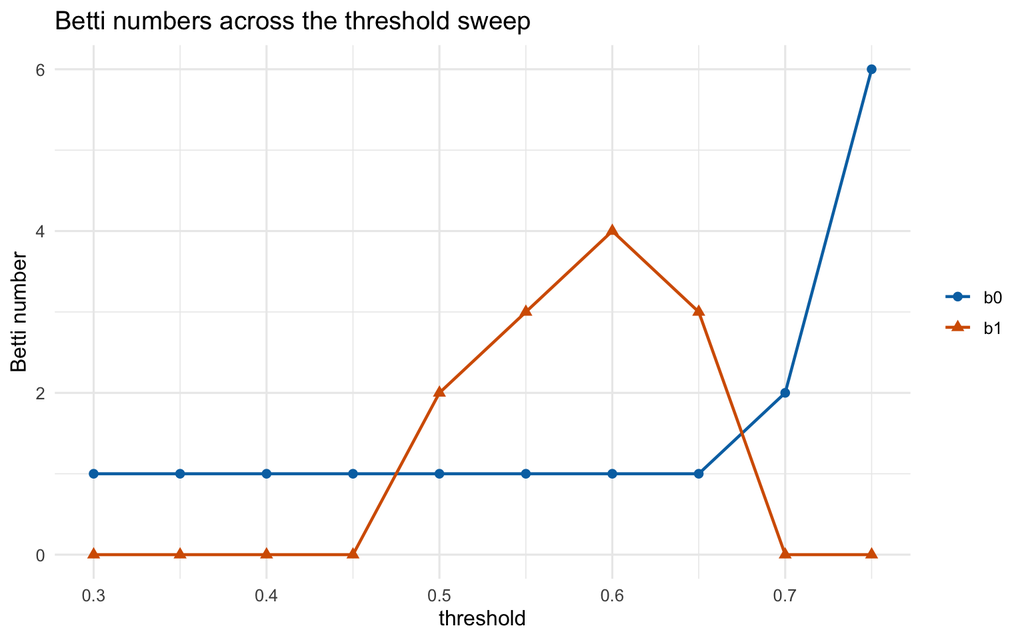

```r
long <- do.call(rbind, lapply(seq(0.3, 0.75, by = 0.05), function(t) {
  b <- betti_numbers(build_simplicial(m, type = "clique", threshold = t))
  data.frame(threshold = t, dimension = c("b0", "b1"),
             betti = c(b[["b0"]], b[["b1"]]))
}))
ggplot2::ggplot(long, ggplot2::aes(x = threshold, y = betti,
                                   colour = dimension, shape = dimension)) +
  ggplot2::geom_line(linewidth = 0.8) +
  ggplot2::geom_point(size = 2.2) +
  ggplot2::scale_colour_manual(values = c(b0 = "#0072B2", b1 = "#D55E00")) +
  ggplot2::labs(x = "threshold", y = "Betti number", colour = NULL,
                shape = NULL,
                title = "Betti numbers across the threshold sweep") +
  ggplot2::theme_minimal(base_size = 12)
```

## On real data

```r
seqs <- split(human_long$code, human_long$session_id)
hon <- build_hon(seqs, max_order = 3, min_freq = 5)
sc_hon <- build_simplicial(hon, type = "pathway")
sc_hon
```

```
Pathway Complex
  9 nodes, 157 simplices, dimension 3
  Density: 61.6%  |  Mean dim: 1.87  |  Euler: 19
  f-vector: (f0=9 f1=36 f2=79 f3=33)
  Betti: b0=1 b2=18
  Nodes: Command, Correct, Frustrate, Inquire, Interrupt, Refine, Request, Specify, Verify
```

```r
betti_numbers(sc_hon)
```

```
b0 b1 b2 b3
 1  0 18  0
```

`b0 = 1`: the pathway complex is connected — no group of actions is isolated. `b1 = 0`: every loop of actions is filled in by some observed pathway. `b2 = 18`: there are **18 independent two-dimensional voids** — configurations of four actions where every triple was observed but the four-way combination never was.

Those 18 are the corpus’s near-misses: patterns the sessions came right up to the edge of and never completed. That is a claim about what is *absent*, which is why it needed a topological method to find.

## What to do next

- **`persistent_homology()`** — the threshold problem, solved properly.
- **`q_analysis()`** — a different notion of connectivity: how strongly do the groups overlap?
- **`build_simplicial()`** — the constructions these numbers describe.

## References

- Edelsbrunner, H., & Harer, J. (2010). *Computational Topology: An Introduction*. American Mathematical Society.
- Ghrist, R. (2008). Barcodes: The persistent topology of data. *Bulletin of the American Mathematical Society*, 45(1), 61-75.